# ATUS_Analysis

```python
import pandas as pd
import re
import matplotlib.pyplot as plt
import seaborn
import numpy as np
```

```python
plt.rc('figure', figsize=(16, 6))
```

```python
%matplotlib inline
```

```python
summary = pd.read_csv("atusdata/atussum_2013/atussum_2013.dat")
summary.info()
```

```
<class 'pandas.core.frame.DataFrame'>
Int64Index: 11385 entries, 0 to 11384
Columns: 413 entries, tucaseid to t500107
dtypes: float64(1), int64(412)
memory usage: 36.0 MB
```

```python
summary.head()
```

|  | tucaseid | TUFINLWGT | TRYHHCHILD | TEAGE | TESEX | PEEDUCA | PTDTRACE | PEHSPNON | GTMETSTA | TELFS | ... | t181501 | t181599 | t181601 | t181801 | t189999 | t500101 | t500103 | t500105 | t500106 | t500107 |
| --- | --- | --- | --- | --- | --- | --- | --- | --- | --- | --- | --- | --- | --- | --- | --- | --- | --- | --- | --- | --- | --- |
| 0 | 20130101130004 | 11899905.662034 | 12 | 22 | 2 | 40 | 8 | 2 | 1 | 5 | ... | 0 | 0 | 0 | 0 | 0 | 0 | 0 | 0 | 0 | 0 |
| 1 | 20130101130112 | 4447638.009513 | 1 | 39 | 1 | 43 | 1 | 2 | 1 | 1 | ... | 0 | 0 | 0 | 0 | 0 | 0 | 0 | 0 | 0 | 0 |
| 2 | 20130101130123 | 10377056.507734 | -1 | 47 | 2 | 40 | 1 | 2 | 1 | 4 | ... | 25 | 0 | 0 | 0 | 0 | 0 | 0 | 0 | 0 | 0 |
| 3 | 20130101130611 | 7731257.992805 | -1 | 50 | 2 | 40 | 1 | 1 | 1 | 1 | ... | 0 | 0 | 0 | 0 | 0 | 0 | 0 | 0 | 0 | 0 |
| 4 | 20130101130616 | 4725269.227067 | -1 | 45 | 2 | 40 | 2 | 2 | 1 | 1 | ... | 0 | 0 | 0 | 0 | 0 | 0 | 0 | 0 | 0 | 0 |

5 rows × 413 columns

```python
summary =summary.replace(-1, np.nan)
```

###### Setting up some initial criteria from the larger sample:

```python
adults_crit = (summary.TEAGE >= 18)
no_children_crit = (summary.TRCHILDNUM == 0)
men_crit = (summary.TESEX == 1)
has_partner = (summary.TRSPPRES <= 2)
has_job = (summary.TELFS <= 2)
partner_has_job = (summary.TESPEMPNOT == 1)
```

###### I want to take a look at how much time men and women are spending on household tasks. I'm looking to compare adults with no children to adults with children. I want to see how time spent on household tasks changes for people when they have children. I also want to analyze the relationship between the sexes - a lot of these tasks are (traditionally, conservatively, etc) "women's work" and I wanted to see whether there is more or less gender equality when there are children in the home.

```python
adults_with_no_children = summary[adults_crit & no_children_crit & has_partner]
adults_with_children = summary[adults_crit & ~no_children_crit & has_partner]
men_with_no_children = summary[adults_crit & no_children_crit & men_crit & has_partner]
men_with_children = summary[adults_crit & ~no_children_crit & men_crit & has_partner]
women_with_no_children = summary[adults_crit & no_children_crit & ~men_crit & has_partner]
women_with_children = summary[adults_crit & ~no_children_crit & ~men_crit & has_partner]
```

```python
def activity_columns(data, activity_code):
    """For the activity code given, return all columns that fall under that activity."""
    col_prefix = "t{}".format(activity_code)
    return [column for column in data.columns if re.match(col_prefix, column)]
```

```python
def average_minutes(data, activity_code):
    cols = activity_columns(data, activity_code)
    activity_data = data[cols]
    activity_sums = activity_data.sum(axis=1)
    data = data[['TUFINLWGT']]
    data['minutes'] = activity_sums
    data = data.rename(columns={"TUFINLWGT": "weight"})
    data['weighted_minutes'] = data.weight * data.minutes
    return round((data.weighted_minutes.sum() / data.weight.sum()), 2)
```

```python
all_adult_with_kids_housework = average_minutes(adults_with_children, "02")
```

```python
all_adult_no_kids_housework = average_minutes(adults_with_no_children, "02")
```

```python
def avg_getter(idgroup, codelist):
    """Returns a list of average minutes for each coded activity in the codelist for the idgroup"""
    particulars = []
    for x in codelist:
        particulars.append(average_minutes(idgroup, x))
    return particulars
```

```python
household_dict = {"0201":"Housework", "0202":"Food & Drink Prep", "0203":"Interior Maintenance", "0204":"Exterior Maintenance",
                  "0205":"Lawn, Garden and Plant Care", "020901":"Financial Management"}
```

```python
household_list = ["0201", "0202", "0203", "0204", "0205", "020901"]
```

```python
labels = ["Housework", "Food & Drink Prep", "Interior Maintentance", "Exterior Maintenance",
          "Lawn, Garden and Plant Care", "Financial Management", "Other"]
```

```python
def household_breakdown(idgroup):
    all_household = average_minutes(idgroup, "02")
    particulars = avg_getter(idgroup, household_list)
    other = all_household - sum(particulars)
    particulars.append(other)
    return particulars
```

```python
x =household_breakdown(men_with_children)
print(x)
```

```
[15.76, 24.940000000000001, 4.5599999999999996, 4.5199999999999996, 12.050000000000001, 1.1000000000000001, 16.270000000000003]
```

```python
mwc_all_household = average_minutes(men_with_children, "02")
mwc_house = household_breakdown(men_with_children)
```

```python
wwc_all_household = average_minutes(women_with_children, "02")
wwc_house = household_breakdown(women_with_children)
```

```python
mnc_all_household = average_minutes(men_with_no_children, "02")
mnc_house = household_breakdown(men_with_no_children)
```

```python
wnc_all_household = average_minutes(women_with_no_children, "02")
wnc_house = household_breakdown(women_with_no_children)
```

```python
total_housework = pd.Series([mnc_all_household, mwc_all_household, wnc_all_household, wwc_all_household], index=(
    ["Men w/out Children", "Men w/ Children", "Women w/out Children", "Women w/ Children"]))
```

###### Let's start out with a basic look at how much total housework men and women do, with and without children. This encompasses all of the activities under the "02" section of the ATUS summary document - "Household Activities." Clearly, some of our assumptions about the existence of "gender roles" in America are visible. Women without children spend around 1.5 times as much time on household activities as men without children. Women with children spend almost twice as much time on household activities as men with children.

###### Having children in the house actually results in about a 20% decrease in the time that men spend on household activities. The time that women spend stays almost exactly the same, although we'll see later that the breakdown of which household activities they are engaged in changes significantly.

```
                      Minutes
Men w/out Children     102.78
Men w/ Children         79.20
Women w/out Children   155.92
Women w/ Children      156.34
```

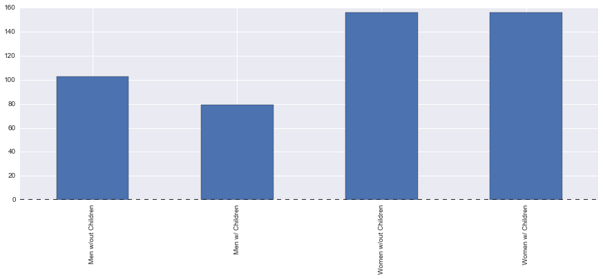

```python
total_housework.plot(kind="bar", figsize=(15,5))
total_df = pd.DataFrame(total_housework)
total_df.columns = ["Minutes"]
print(total_df)
plt.show()
```

```python
ratio_men = mnc_all_household / all_adult_no_kids_housework
ratio_women = wnc_all_household / all_adult_no_kids_housework
ratio_men_kids = mwc_all_household / all_adult_with_kids_housework
ratio_women_kids = wwc_all_household /all_adult_with_kids_housework
```

```python
ratio_men + ratio_women
```

```
1.9933734011403912
```

```python
ratio_men_kids + ratio_women_kids
```

```
2.0190296588376482
```

###### I wanted to look at how things break down when we take a more detailed look at the household tasks on which people are spending their time. I looked at 6 categories: housework(includes interior cleaning, picking up, laundry), food and drink preparation, interior maintenance, exterior maintenance, lawn and garden care, and financial management. I wanted to make sure I looked at some activities that weren't quite as historically gendered as cooking or cleaning. I also tracked an "other" category that consisted simply of all other time that individuals of each group spent on household activities.

```python
mwc = pd.Series(mwc_house, index=labels)
mnc = pd.Series(mnc_house, index=labels)
wwc = pd.Series(wwc_house, index=labels)
wnc = pd.Series(wnc_house, index=labels)

housework_df = pd.DataFrame(mnc, index=labels)

housework_df.columns = ["Men w/out Children"]
housework_df['Men w/ Children'] = mwc
housework_df['Women w/out Children'] = wnc
housework_df['Women w/ Children'] = wwc
housework_df
```

|  | Men w/out Children | Men w/ Children | Women w/out Children | Women w/ Children |
| --- | --- | --- | --- | --- |
| Housework | 14.20 | 15.76 | 57.24 | 66.46 |
| Food & Drink Prep | 20.57 | 24.94 | 52.13 | 66.72 |
| Interior Maintentance | 8.26 | 4.56 | 4.41 | 2.24 |
| Exterior Maintenance | 7.19 | 4.52 | 2.88 | 0.92 |
| Lawn, Garden and Plant Care | 26.39 | 12.05 | 11.37 | 5.04 |
| Financial Management | 1.93 | 1.10 | 3.54 | 1.08 |
| Other | 24.24 | 16.27 | 24.35 | 13.88 |

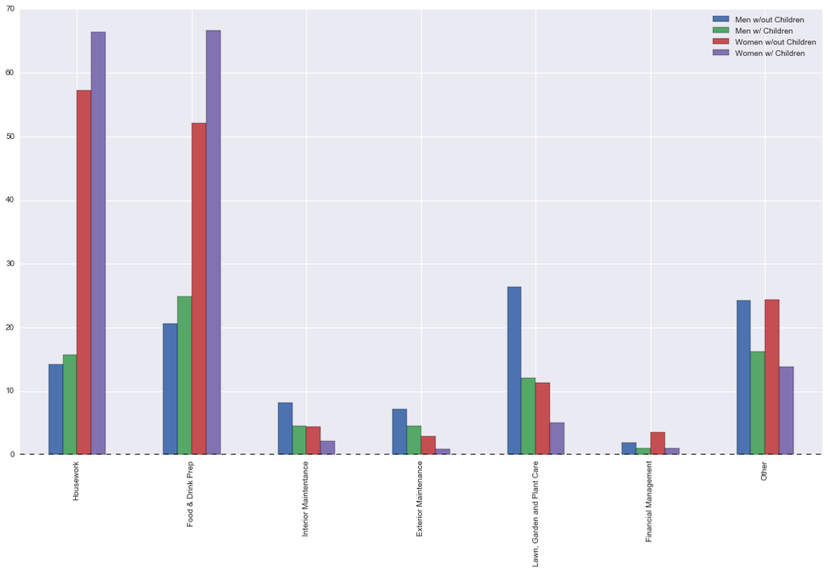

```python
housework_df.plot(kind="bar", figsize=(18,10))
plt.show()
```

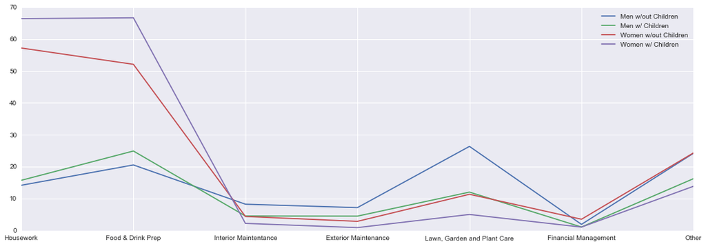

```python
housework_df.plot(figsize=(18,6))
plt.show()
```

###### The data below provides a really interesting look at how things change when children are added to the equation. For men and women, housework and food/drink prep increase. For women, they increase substantially. In all other categories, they spend less time after they have children. When there are children in the house, people focus on what's absolutely necessary: picking up the house and feeding the family. This dynamic is even more evident in women.

```python
housework_df["Child Diff Men"] = housework_df["Men w/ Children"] - housework_df["Men w/out Children"]
housework_df["Child Diff Women"] = housework_df["Women w/ Children"] - housework_df["Women w/out Children"]
housework_df
```

|  | Men w/out Children | Men w/ Children | Women w/out Children | Women w/ Children | Child Diff Men | Child Diff Women |
| --- | --- | --- | --- | --- | --- | --- |
| Housework | 14.20 | 15.76 | 57.24 | 66.46 | 1.56 | 9.22 |
| Food & Drink Prep | 20.57 | 24.94 | 52.13 | 66.72 | 4.37 | 14.59 |
| Interior Maintentance | 8.26 | 4.56 | 4.41 | 2.24 | -3.70 | -2.17 |
| Exterior Maintenance | 7.19 | 4.52 | 2.88 | 0.92 | -2.67 | -1.96 |
| Lawn, Garden and Plant Care | 26.39 | 12.05 | 11.37 | 5.04 | -14.34 | -6.33 |
| Financial Management | 1.93 | 1.10 | 3.54 | 1.08 | -0.83 | -2.46 |
| Other | 24.24 | 16.27 | 24.35 | 13.88 | -7.97 | -10.47 |

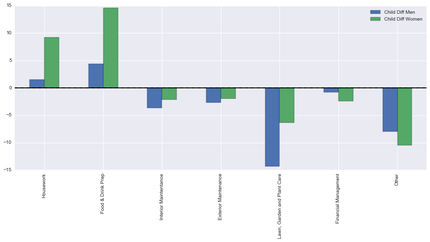

```python
housework_df[["Child Diff Men", "Child Diff Women"]].plot(kind="bar", figsize=(15,6))
plt.axhline(y=0, color="black")
plt.show()
```

```python
women_chart = housework_df[["Women w/out Children", "Women w/ Children", "Child Diff Women"]]
women_chart
```

|  | Women w/out Children | Women w/ Children | Child Diff Women |
| --- | --- | --- | --- |
| Housework | 57.24 | 66.46 | 9.22 |
| Food & Drink Prep | 52.13 | 66.72 | 14.59 |
| Interior Maintentance | 4.41 | 2.24 | -2.17 |
| Exterior Maintenance | 2.88 | 0.92 | -1.96 |
| Lawn, Garden and Plant Care | 11.37 | 5.04 | -6.33 |
| Financial Management | 3.54 | 1.08 | -2.46 |
| Other | 24.35 | 13.88 | -10.47 |

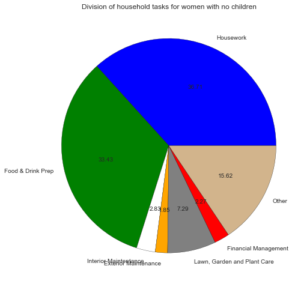

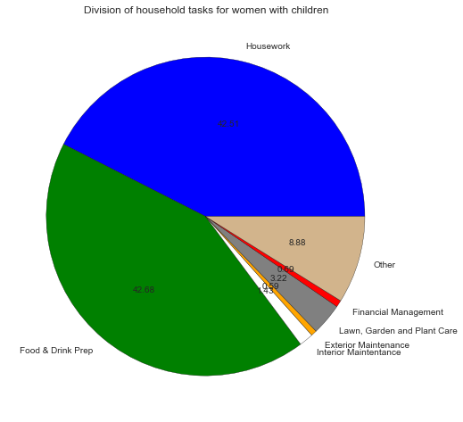

```python
wnc.plot(kind="pie", figsize=(8,8), colors = ['b', 'g', 'white', 'orange', 'grey', 'red', 'tan'], autopct='%.2f')
plt.title("Division of household tasks for women with no children")
plt.show()
#print("")
wwc.plot(kind="pie", figsize=(8,8), colors = ['b', 'g', 'white', 'orange', 'grey', 'red', 'tan'], autopct='%.2f')
plt.title("Division of household tasks for women with children")
plt.show()
```

###### Let's even the playing field a bit. Let's look at men and women who both work, and how their share of household tasks changes with children.

```python
working_male = summary[adults_crit & no_children_crit & men_crit & has_partner & has_job & partner_has_job]
working_male_kids = summary[adults_crit & ~no_children_crit & men_crit & has_partner & has_job & partner_has_job]
working_female = summary[adults_crit & no_children_crit & ~men_crit & has_partner & has_job & partner_has_job]
working_female_kids = summary[adults_crit & ~no_children_crit & ~men_crit & has_partner & has_job & partner_has_job]
```

```python
wm_all_household = average_minutes(working_male, "02")
wm_house = household_breakdown(working_male)
```

```python
wmk_all_household = average_minutes(working_male_kids, "02")
wmk_house = household_breakdown(working_male_kids)
```

```python
wf_all_household = average_minutes(working_female, "02")
wf_house = household_breakdown(working_female)
```

```python
wfk_all_household = average_minutes(working_female_kids, "02")
wfk_house = household_breakdown(working_female_kids)
```

```python
total_working_housework = pd.Series([wm_all_household, wmk_all_household, wf_all_household, wfk_all_household], index=(
    ["Men w/out Children", "Men w/ Children", "Women w/out Children", "Women w/ Children"]))
```

```
                      Minutes
Men w/out Children      90.85
Men w/ Children         78.73
Women w/out Children   125.47
Women w/ Children      132.35
```

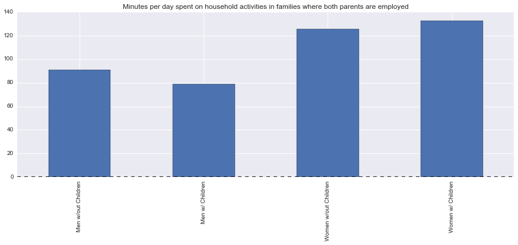

```python
total_working_housework.plot(kind="bar", figsize=(15,5))
total_working_df = pd.DataFrame(total_working_housework)
total_working_df.columns = ["Minutes"]
print(total_working_df)
plt.title("Minutes per day spent on household activities in families where both parents are employed")
plt.show()
```

###### We can see that when both partners are working, there's a general decrease across the board in terms of total time spent on housework. The exception is men with children, who contrbute the same amount, whether or not both partners are working.

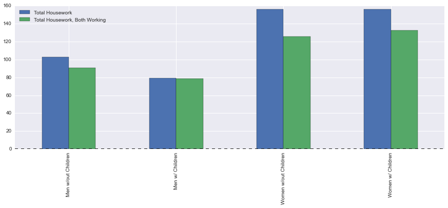

```python
all_total_df = pd.DataFrame(total_housework)
all_total_df.columns = ["Total Housework"]
all_total_df["Total Housework, Both Working"] = total_working_housework
all_total_df.plot(kind="bar", figsize=(15,5))
plt.show()
```

```python
mwc = pd.Series(mwc_house, index=labels)
mnc = pd.Series(mnc_house, index=labels)
wwc = pd.Series(wwc_house, index=labels)
wnc = pd.Series(wnc_house, index=labels)

wm = pd.Series(wm_house, index=labels)
wmk = pd.Series(wmk_house, index=labels)
wf = pd.Series(wf_house, index=labels)
wfk = pd.Series(wfk_house, index=labels)
large_housework_df = pd.DataFrame(mnc, index=labels)
large_housework_df.columns = ["Men w/out Children"]
large_housework_df['Men w/ Children'] = mwc
large_housework_df['Both Working, Men w/out Children'] = wmk
large_housework_df['Both Working, Men w/ Children'] = wm
large_housework_df['Women w/out Children'] = wnc
large_housework_df['Women w/ Children'] = wwc
large_housework_df['Both Working, Women w/out Children'] = wf
large_housework_df['Both Working, Women w/ Children'] = wfk

large_housework_df
```

|  | Men w/out Children | Men w/ Children | Both Working, Men w/out Children | Both Working, Men w/ Children | Women w/out Children | Women w/ Children | Both Working, Women w/out Children | Both Working, Women w/ Children |
| --- | --- | --- | --- | --- | --- | --- | --- | --- |
| Housework | 14.20 | 15.76 | 13.81 | 12.78 | 57.24 | 66.46 | 48.26 | 53.76 |
| Food & Drink Prep | 20.57 | 24.94 | 27.04 | 17.96 | 52.13 | 66.72 | 39.42 | 55.63 |
| Interior Maintentance | 8.26 | 4.56 | 4.42 | 11.16 | 4.41 | 2.24 | 5.44 | 2.13 |
| Exterior Maintenance | 7.19 | 4.52 | 6.33 | 4.39 | 2.88 | 0.92 | 2.76 | 1.11 |
| Lawn, Garden and Plant Care | 26.39 | 12.05 | 10.25 | 21.19 | 11.37 | 5.04 | 7.02 | 4.72 |
| Financial Management | 1.93 | 1.10 | 0.75 | 2.15 | 3.54 | 1.08 | 1.70 | 0.86 |
| Other | 24.24 | 16.27 | 16.13 | 21.22 | 24.35 | 13.88 | 20.87 | 14.14 |

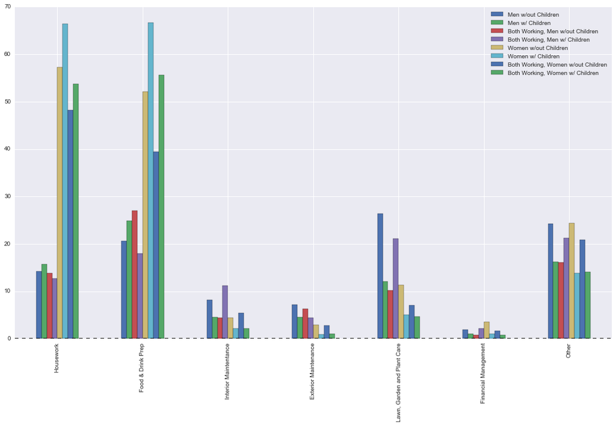

```python
large_housework_df.plot(kind="bar", figsize=(18,10))
plt.show()
```

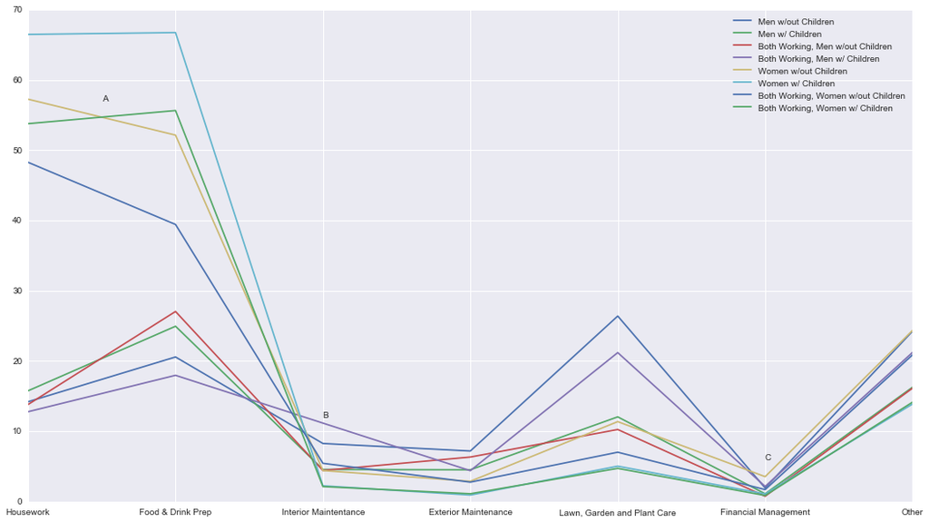

```python
large_housework_df.plot(figsize=(18,10))
plt.annotate("A", (.5,57))
plt.annotate("B", (2,12))
plt.annotate("C", (5,6))
plt.show()
```

###### I tried to merge in the cpsdata to see how things differed by region. But the data I was getting back didn't make any sense.

```python
cpsdata = pd.read_csv("atusdata/atuscps_2013/atuscps_2013.dat")
```

```python
#cpsdata.head()
```

```python
cpsdata = cpsdata.rename(columns={'TUCASEID': 'tucaseid'})
```

```python
#cpsdata.head()
```

```python
merged = pd.merge(summary, cpsdata, left_on="tucaseid", right_on="tucaseid")
merged.info()
```

```
<class 'pandas.core.frame.DataFrame'>
Int64Index: 29871 entries, 0 to 29870
Columns: 787 entries, tucaseid to PRDASIAN
dtypes: float64(13), int64(774)
memory usage: 179.6 MB
```

```python
#merged.head()
```

```python
xadults_crit = (merged.TEAGE >= 18)
xno_children_crit = (merged.TRCHILDNUM == 0)
xmen_crit = (merged.TESEX == 1)
xhas_partner = (merged.TRSPPRES <= 2)
xhas_job = (merged.TELFS <= 2)
xpartner_has_job = (merged.TESPEMPNOT == 1)
northeast = (merged.GEREG == 1)
midwest = (merged.GEREG == 2)
south = (merged.GEREG == 3)
west = (merged.GEREG == 4)
```

```python
xworking_male = summary[xadults_crit & xno_children_crit & xmen_crit & xhas_partner & xhas_job & xpartner_has_job]
xworking_male_kids = summary[xadults_crit & ~xno_children_crit & xmen_crit & xhas_partner & xhas_job & xpartner_has_job]
xworking_female = summary[xadults_crit & xno_children_crit & ~xmen_crit & xhas_partner & xhas_job & xpartner_has_job]
xworking_female_kids = summary[xadults_crit & ~xno_children_crit & ~xmen_crit & xhas_partner & xhas_job & xpartner_has_job]
```

```python
ne_male = average_minutes(xworking_male[northeast], "02")
ne_male_kids = average_minutes(xworking_male_kids[northeast], "02")
ne_female = average_minutes(xworking_female[northeast], "02")
ne_female_kids = average_minutes(xworking_female_kids[northeast], "02")
```

```python
[ne_male, ne_male_kids, ne_female, ne_female_kids]
```

```
[130.33000000000001, 107.36, 107.26000000000001, 103.59]
```

```python
mw_male = average_minutes(xworking_male[midwest], "02")
mw_male_kids = average_minutes(xworking_male_kids[midwest], "02")
mw_female = average_minutes(xworking_female[midwest], "02")
mw_female_kids = average_minutes(xworking_female_kids[midwest], "02")
```

```python
[mw_male, mw_male_kids, mw_female, mw_female_kids]
```

```
[89.030000000000001, 113.70999999999999, 112.31, 126.95999999999999]
```

```python
s_male = average_minutes(xworking_male[south], "02")
s_male_kids = average_minutes(xworking_male_kids[south], "02")
s_female = average_minutes(xworking_female[south], "02")
s_female_kids = average_minutes(xworking_female_kids[south], "02")
```

```python
[s_male, s_male_kids, s_female, s_female_kids]
```

```
[119.39, 105.68000000000001, 93.920000000000002, 111.38]
```

```python
w_male = average_minutes(xworking_male[west], "02")
w_male_kids = average_minutes(xworking_male_kids[west], "02")
w_female = average_minutes(xworking_female[west], "02")
w_female_kids = average_minutes(xworking_female_kids[west], "02")
```

```python
[w_male, w_male_kids, w_female, w_female_kids]
```

```
[84.370000000000005, 111.59999999999999, 85.799999999999997, 105.77]
```